# Dada2_report

Ramón Gallego

1/9/2018

## Dada2 report

You have successfully split your libraries into a pair (or two) of fastq files per sample. Now let’s import the output of demultiplex_both_fastq.sh

First load the packages. And let’s update the parameters we need

```
## # A tibble: 6 x 3
##   Full_Id                           fastq_header Sample
##   <chr>                             <chr>        <chr>
## 1 ID1=Lib_F;ID2A=TCGCAT;ID2B=ATGCGA Lib_F_TCGCAT NR_Ac_1_Jul_A_r4
## 2 ID1=Lib_D;ID2A=ACAGCA;ID2B=TGCTGT Lib_D_ACAGCA NR_Ac_3_Jul_A_r4
## 3 ID1=Lib_G;ID2A=ACACAC;ID2B=GTGTGT Lib_G_ACACAC NR_Ac_6_Jul_A_r4
## 4 ID1=Lib_F;ID2A=ACACAC;ID2B=GTGTGT Lib_F_ACACAC NR_Ac_10_Jul_A_r4
## 5 ID1=Lib_C;ID2A=ACACAC;ID2B=GTGTGT Lib_C_ACACAC NR_Ac_15_Jul_A_r4
## 6 ID1=Lib_B;ID2A=ACATGT;ID2B=ACATGT Lib_B_ACATGT NR_Ac_1_Aug_A_r4
```

```
## [1] "/Users/ramongallego/GoogleDrive/Raw_data/Halo/EJP_ROUND4/Lib-B-EJP-ROUND4_S2_L001_R1_001.fastq"
```

Firstly, we’ll find the patterns that separate our Fwd, Rev, .1 and .2 files. look at the quality of the .1 and .2 reads

```r
F1s <- sort(list.files(path1, pattern="_Fwd.1.fastq", full.names = TRUE))
F2s <- sort(list.files(path1, pattern="_Fwd.2.fastq", full.names = TRUE))
R1s <- sort(list.files(path1, pattern="_Rev.1.fastq", full.names = TRUE))
R2s <- sort(list.files(path1, pattern="_Rev.2.fastq", full.names = TRUE))

# Extract sample names, assuming filenames have format: SAMPLENAME_XXX.fastq
sample.names <- str_replace(basename(F1s), "_Fwd.1.fastq","")

#Now use only those that reflect a real sample

good.sample.names<-sample.names[sample.names %in% sample.map$fastq_header]
# Introduce here the biological counterpart of the fastq file

real.sample.name <- sample.map[,3][match(good.sample.names,sample.map$fastq_header),1]

# Now subset the number of files to be looked at

F1sgood<-F1s[sample.names %in% sample.map$fastq_header]
F2sgood<-F2s[sample.names %in% sample.map$fastq_header]
R1sgood<-R1s[sample.names %in% sample.map$fastq_header]
R2sgood<-R2s[sample.names %in% sample.map$fastq_header]
```

A nice idea is to plot the Quality of the F1 reads

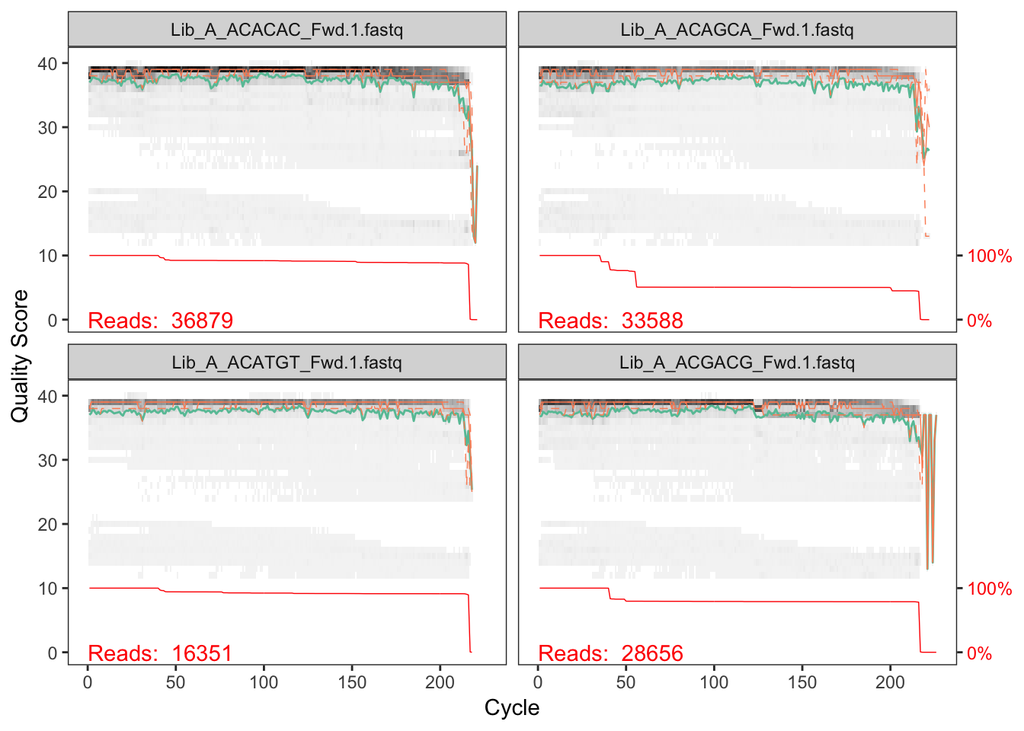

The quality should be similar to that of the Reverse .1 reads

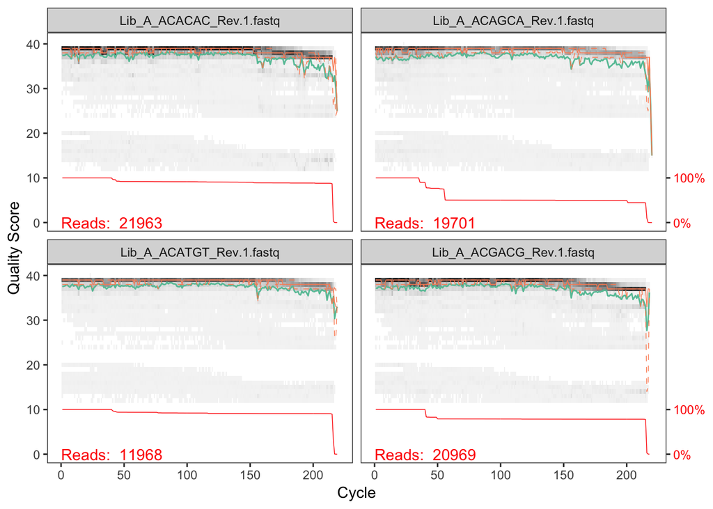

On the other hand, the quality of the .2 reads should decrease earlier

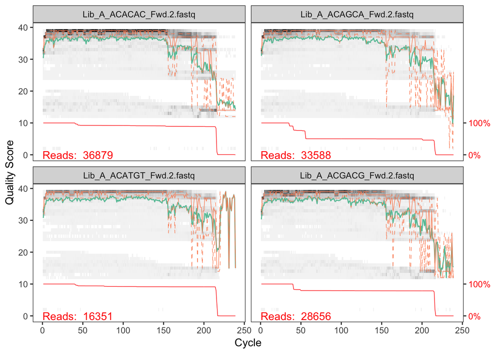

## Now start with the trimming of each read based on the quality we just plotted

```r
filt_path <- file.path(params$folder, "/filtered") # Place filtered files in filtered/ subdirectory
filtF1s <- file.path(filt_path, paste0(good.sample.names, "_F1_filt.fastq.gz"))
filtF2s <- file.path(filt_path, paste0(good.sample.names, "_F2_filt.fastq.gz"))
out_Fs <- filterAndTrim(F1sgood, filtF1s, F2sgood, filtF2s, truncLen=c(200,200),
                      maxN=0, maxEE=c(2,2), truncQ=2, rm.phix=TRUE,
                      compress=TRUE, multithread=TRUE) # On Windows set multithread=FALSE
```

```
## Creating output directory: /Users/ramongallego/fastqs_demultiplexed_for_DADA2/demultiplexed_20190214_1601//filtered
```

```r
filtR1s <- file.path(filt_path, paste0(good.sample.names, "_R1_filt.fastq.gz"))
filtR2s <- file.path(filt_path, paste0(good.sample.names, "_R2_filt.fastq.gz"))
out_Rs <- filterAndTrim(R1sgood, filtR1s, R2sgood, filtR2s, truncLen=c(200,200),
                      maxN=0, maxEE=c(2,2), truncQ=2, rm.phix=TRUE,
                      compress=TRUE, multithread=TRUE)
```

```r
out_Fs_tibble<-tibble(file=dimnames(out_Fs)[[1]], reads.out=out_Fs[,2])
out_Rs_tibble<-tibble(file=dimnames(out_Rs)[[1]], reads.out=out_Rs[,2])
out_Fs_tibble
```

```
## # A tibble: 63 x 2
##    file                     reads.out
##    <chr>                        <dbl>
##  1 Lib_A_ACACAC_Fwd.1.fastq     30235
##  2 Lib_A_ACAGCA_Fwd.1.fastq     15301
##  3 Lib_A_ACATGT_Fwd.1.fastq     14012
##  4 Lib_A_ACGACG_Fwd.1.fastq     20518
##  5 Lib_A_ATATCG_Fwd.1.fastq      7589
##  6 Lib_A_CTCGCA_Fwd.1.fastq     27350
##  7 Lib_A_GCGCTC_Fwd.1.fastq     19694
##  8 Lib_A_GTCTCT_Fwd.1.fastq     34780
##  9 Lib_A_TCGCAT_Fwd.1.fastq     26028
## 10 Lib_B_ACACAC_Fwd.1.fastq     14630
## # … with 53 more rows
```

Now the first crucial step: learning the error rates that would be different for fwd and rev reads

```r
errF1 <- learnErrors(filtF1s, multithread=TRUE,verbose = 0)
errF2 <- learnErrors(filtF2s, multithread=TRUE,verbose = 0)
errR1 <- learnErrors(filtR1s, multithread=TRUE,verbose = 0)
errR2 <- learnErrors(filtR2s, multithread=TRUE,verbose = 0)

# Write errors to csv to see if they matter at all
tosave <- list(errF1, errF2, errR1, errR2)

saveRDS(tosave, file = "all.errors.rds")
```

Which we can plot now to see the error rates between transitions of each pair of nt

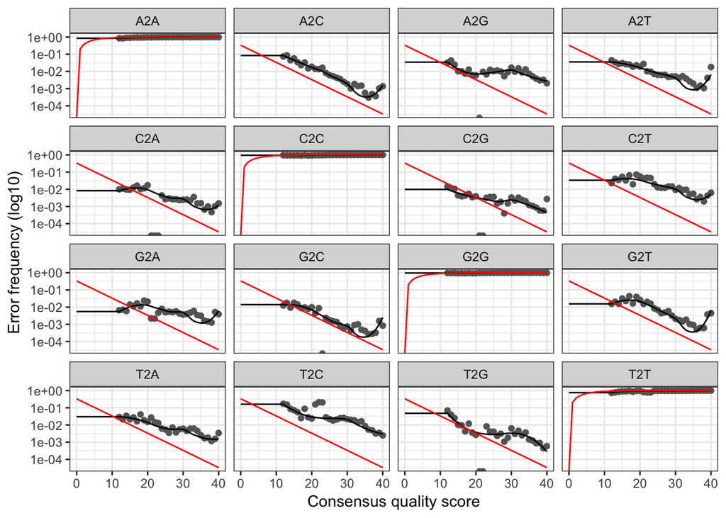

```r
plotErrors(errF1, nominalQ = T)
```

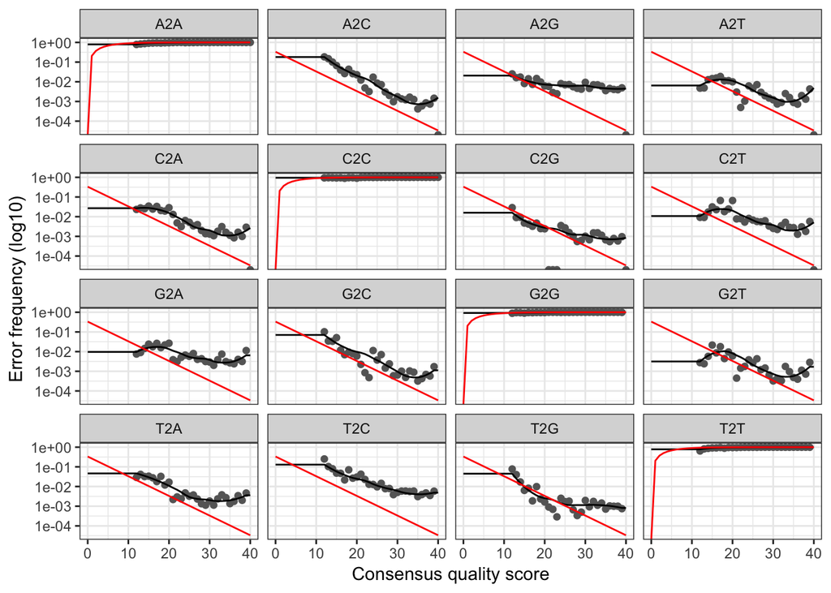

```r
plotErrors(errF2, nominalQ = T)
```

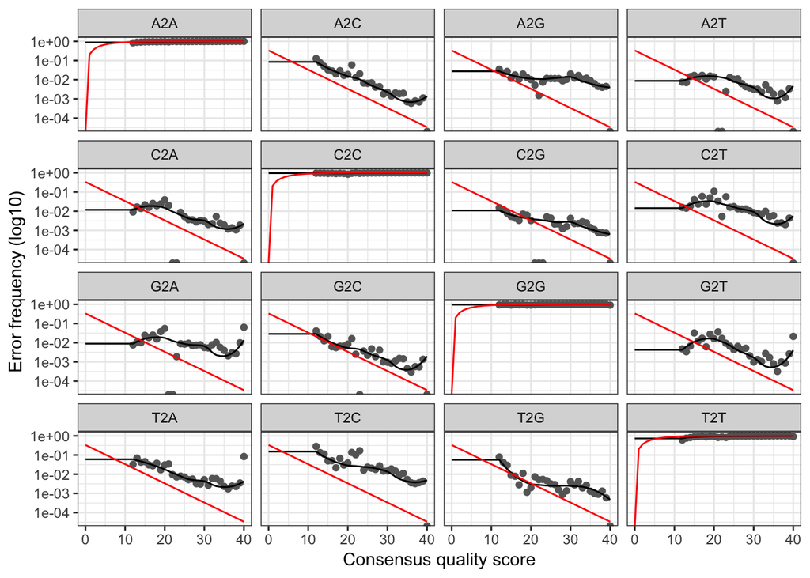

```r
plotErrors(errR1, nominalQ = T)
```

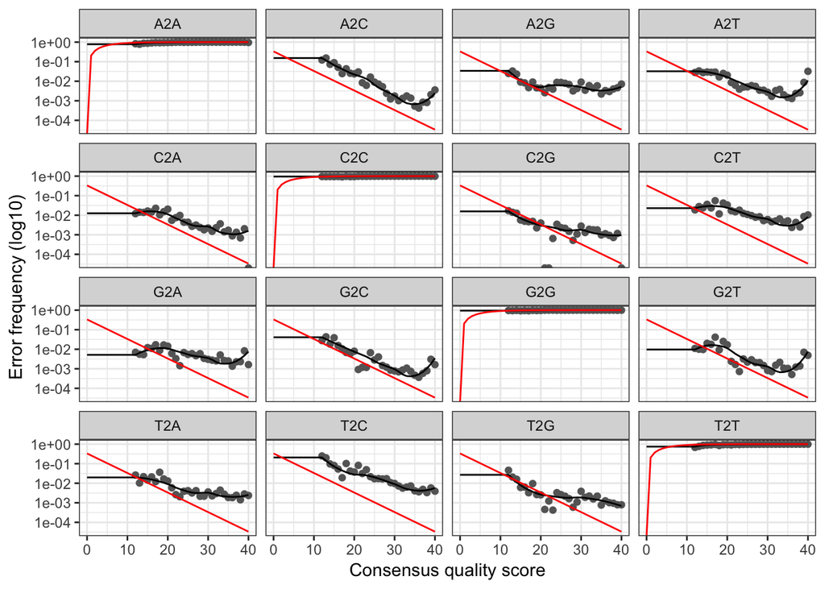

```r
plotErrors(errR2, nominalQ = T)
```

## Now go to the dereplication step

## And finally an inference of the sample composition

```r
dadaF1s <- dada(derepF1s, err = errF1, multithread = TRUE)
```

```
## Sample 1 - 30235 reads in 7794 unique sequences.
## Sample 2 - 15301 reads in 5340 unique sequences.
## Sample 3 - 14012 reads in 4720 unique sequences.
## Sample 4 - 20518 reads in 4584 unique sequences.
## Sample 5 - 7589 reads in 2611 unique sequences.
## Sample 6 - 27350 reads in 8976 unique sequences.
## Sample 7 - 19694 reads in 5152 unique sequences.
## Sample 8 - 34780 reads in 8160 unique sequences.
## Sample 9 - 26028 reads in 7888 unique sequences.
## Sample 10 - 14630 reads in 4494 unique sequences.
## Sample 11 - 8922 reads in 2944 unique sequences.
## Sample 12 - 6565 reads in 2724 unique sequences.
## Sample 13 - 13273 reads in 3796 unique sequences.
## Sample 14 - 9629 reads in 3735 unique sequences.
## Sample 15 - 20325 reads in 7128 unique sequences.
## Sample 16 - 15281 reads in 5389 unique sequences.
## Sample 17 - 8250 reads in 3198 unique sequences.
## Sample 18 - 80429 reads in 24803 unique sequences.
## Sample 19 - 10021 reads in 5298 unique sequences.
## Sample 20 - 23377 reads in 7269 unique sequences.
## Sample 21 - 23319 reads in 5140 unique sequences.
## Sample 22 - 15913 reads in 5410 unique sequences.
## Sample 23 - 16386 reads in 4539 unique sequences.
## Sample 24 - 14694 reads in 4412 unique sequences.
## Sample 25 - 14881 reads in 2491 unique sequences.
## Sample 26 - 22916 reads in 6984 unique sequences.
## Sample 27 - 10999 reads in 3185 unique sequences.
## Sample 28 - 19808 reads in 6210 unique sequences.
## Sample 29 - 21218 reads in 6855 unique sequences.
## Sample 30 - 46957 reads in 13329 unique sequences.
## Sample 31 - 32413 reads in 7213 unique sequences.
## Sample 32 - 19434 reads in 6229 unique sequences.
## Sample 33 - 58 reads in 52 unique sequences.
## Sample 34 - 4442 reads in 1288 unique sequences.
## Sample 35 - 32204 reads in 9427 unique sequences.
## Sample 36 - 19038 reads in 5744 unique sequences.
## Sample 37 - 16067 reads in 4052 unique sequences.
## Sample 38 - 16344 reads in 6750 unique sequences.
## Sample 39 - 12827 reads in 3877 unique sequences.
## Sample 40 - 19065 reads in 5260 unique sequences.
```

[output cut: 8 more lines]

```
## Sample 49 - 11451 reads in 3045 unique sequences.
## Sample 50 - 23 reads in 20 unique sequences.
## Sample 51 - 50064 reads in 13601 unique sequences.
## Sample 52 - 30 reads in 30 unique sequences.
## Sample 53 - 43245 reads in 11992 unique sequences.
## Sample 54 - 16218 reads in 5763 unique sequences.
## Sample 55 - 21265 reads in 7155 unique sequences.
## Sample 56 - 33283 reads in 10353 unique sequences.
## Sample 57 - 11819 reads in 2301 unique sequences.
## Sample 58 - 9821 reads in 1637 unique sequences.
## Sample 59 - 30162 reads in 9004 unique sequences.
## Sample 60 - 13521 reads in 5911 unique sequences.
## Sample 61 - 36 reads in 30 unique sequences.
## Sample 62 - 20516 reads in 4852 unique sequences.
## Sample 63 - 55868 reads in 14359 unique sequences.
```

```r
dadaF2s <- dada(derepF2s, err = errF2, multithread = TRUE)
```

```
## Sample 1 - 30235 reads in 12712 unique sequences.
## Sample 2 - 15301 reads in 7042 unique sequences.
## Sample 3 - 14012 reads in 6576 unique sequences.
## Sample 4 - 20518 reads in 8044 unique sequences.
## Sample 5 - 7589 reads in 3580 unique sequences.
## Sample 6 - 27350 reads in 12429 unique sequences.
## Sample 7 - 19694 reads in 8452 unique sequences.
## Sample 8 - 34780 reads in 13516 unique sequences.
## Sample 9 - 26028 reads in 11355 unique sequences.
## Sample 10 - 14630 reads in 6689 unique sequences.
## Sample 11 - 8922 reads in 4513 unique sequences.
## Sample 12 - 6565 reads in 3716 unique sequences.
## Sample 13 - 13273 reads in 5879 unique sequences.
## Sample 14 - 9629 reads in 5033 unique sequences.
## Sample 15 - 20325 reads in 10133 unique sequences.
## Sample 16 - 15281 reads in 7390 unique sequences.
## Sample 17 - 8250 reads in 4190 unique sequences.
## Sample 18 - 80429 reads in 35606 unique sequences.
## Sample 19 - 10021 reads in 6858 unique sequences.
## Sample 20 - 23377 reads in 10593 unique sequences.
## Sample 21 - 23319 reads in 8968 unique sequences.
## Sample 22 - 15913 reads in 7600 unique sequences.
## Sample 23 - 16386 reads in 6612 unique sequences.
## Sample 24 - 14694 reads in 7612 unique sequences.
## Sample 25 - 14881 reads in 5687 unique sequences.
## Sample 26 - 22916 reads in 9873 unique sequences.
## Sample 27 - 10999 reads in 4528 unique sequences.
## Sample 28 - 19808 reads in 8868 unique sequences.
## Sample 29 - 21218 reads in 9635 unique sequences.
## Sample 30 - 46957 reads in 19329 unique sequences.
## Sample 31 - 32413 reads in 12683 unique sequences.
## Sample 32 - 19434 reads in 8632 unique sequences.
## Sample 33 - 58 reads in 54 unique sequences.
## Sample 34 - 4442 reads in 1788 unique sequences.
## Sample 35 - 32204 reads in 13955 unique sequences.
## Sample 36 - 19038 reads in 7718 unique sequences.
## Sample 37 - 16067 reads in 5950 unique sequences.
## Sample 38 - 16344 reads in 9108 unique sequences.
## Sample 39 - 12827 reads in 5041 unique sequences.
## Sample 40 - 19065 reads in 7387 unique sequences.
```

[output cut: 8 more lines]

```
## Sample 49 - 11451 reads in 4954 unique sequences.
## Sample 50 - 23 reads in 21 unique sequences.
## Sample 51 - 50064 reads in 21051 unique sequences.
## Sample 52 - 30 reads in 29 unique sequences.
## Sample 53 - 43245 reads in 17909 unique sequences.
## Sample 54 - 16218 reads in 7922 unique sequences.
## Sample 55 - 21265 reads in 9999 unique sequences.
## Sample 56 - 33283 reads in 14765 unique sequences.
## Sample 57 - 11819 reads in 4436 unique sequences.
## Sample 58 - 9821 reads in 3392 unique sequences.
## Sample 59 - 30162 reads in 13358 unique sequences.
## Sample 60 - 13521 reads in 8640 unique sequences.
## Sample 61 - 36 reads in 31 unique sequences.
## Sample 62 - 20516 reads in 8084 unique sequences.
## Sample 63 - 55868 reads in 22614 unique sequences.
```

```r
dadaR1s <- dada(derepR1s, err = errR1, multithread = TRUE)
```

```
## Sample 1 - 18087 reads in 5399 unique sequences.
## Sample 2 - 9062 reads in 3626 unique sequences.
## Sample 3 - 10294 reads in 3616 unique sequences.
## Sample 4 - 15271 reads in 3909 unique sequences.
## Sample 5 - 4774 reads in 1934 unique sequences.
## Sample 6 - 17619 reads in 6406 unique sequences.
## Sample 7 - 13164 reads in 4230 unique sequences.
## Sample 8 - 25170 reads in 7176 unique sequences.
## Sample 9 - 18378 reads in 6362 unique sequences.
## Sample 10 - 7998 reads in 2982 unique sequences.
## Sample 11 - 5068 reads in 2037 unique sequences.
## Sample 12 - 4779 reads in 2037 unique sequences.
## Sample 13 - 9343 reads in 3100 unique sequences.
## Sample 14 - 6181 reads in 2719 unique sequences.
## Sample 15 - 13018 reads in 5218 unique sequences.
## Sample 16 - 10514 reads in 3945 unique sequences.
## Sample 17 - 6043 reads in 2519 unique sequences.
## Sample 18 - 57258 reads in 19072 unique sequences.
## Sample 19 - 6397 reads in 3551 unique sequences.
## Sample 20 - 14525 reads in 5262 unique sequences.
## Sample 21 - 17144 reads in 4401 unique sequences.
## Sample 22 - 12003 reads in 4323 unique sequences.
## Sample 23 - 10586 reads in 3270 unique sequences.
## Sample 24 - 9869 reads in 3822 unique sequences.
## Sample 25 - 11843 reads in 2402 unique sequences.
## Sample 26 - 17766 reads in 5541 unique sequences.
## Sample 27 - 7670 reads in 2301 unique sequences.
## Sample 28 - 11611 reads in 4098 unique sequences.
## Sample 29 - 12396 reads in 4476 unique sequences.
## Sample 30 - 34503 reads in 10711 unique sequences.
## Sample 31 - 23406 reads in 5977 unique sequences.
## Sample 32 - 12454 reads in 4591 unique sequences.
## Sample 33 - 36 reads in 33 unique sequences.
## Sample 34 - 3080 reads in 904 unique sequences.
## Sample 35 - 24508 reads in 8193 unique sequences.
## Sample 36 - 13323 reads in 4055 unique sequences.
## Sample 37 - 9300 reads in 2653 unique sequences.
## Sample 38 - 9554 reads in 4382 unique sequences.
## Sample 39 - 8856 reads in 2916 unique sequences.
## Sample 40 - 13802 reads in 4222 unique sequences.
```

[output cut: 8 more lines]

```
## Sample 49 - 6780 reads in 2202 unique sequences.
## Sample 50 - 25 reads in 23 unique sequences.
## Sample 51 - 27234 reads in 8620 unique sequences.
## Sample 52 - 34 reads in 30 unique sequences.
## Sample 53 - 25915 reads in 8791 unique sequences.
## Sample 54 - 9086 reads in 3529 unique sequences.
## Sample 55 - 11205 reads in 4324 unique sequences.
## Sample 56 - 17943 reads in 6391 unique sequences.
## Sample 57 - 8304 reads in 2056 unique sequences.
## Sample 58 - 7385 reads in 1502 unique sequences.
## Sample 59 - 17263 reads in 5769 unique sequences.
## Sample 60 - 8587 reads in 4037 unique sequences.
## Sample 61 - 20 reads in 20 unique sequences.
## Sample 62 - 13667 reads in 3909 unique sequences.
## Sample 63 - 37328 reads in 11196 unique sequences.
```

```r
dadaR2s <- dada(derepR2s, err = errR2, multithread = TRUE)
```

```
## Sample 1 - 18087 reads in 7658 unique sequences.
## Sample 2 - 9062 reads in 4516 unique sequences.
## Sample 3 - 10294 reads in 4893 unique sequences.
## Sample 4 - 15271 reads in 5836 unique sequences.
## Sample 5 - 4774 reads in 2445 unique sequences.
## Sample 6 - 17619 reads in 8783 unique sequences.
## Sample 7 - 13164 reads in 5716 unique sequences.
## Sample 8 - 25170 reads in 9209 unique sequences.
## Sample 9 - 18378 reads in 8734 unique sequences.
## Sample 10 - 7998 reads in 3757 unique sequences.
## Sample 11 - 5068 reads in 2571 unique sequences.
## Sample 12 - 4779 reads in 2840 unique sequences.
## Sample 13 - 9343 reads in 4070 unique sequences.
## Sample 14 - 6181 reads in 3425 unique sequences.
## Sample 15 - 13018 reads in 6846 unique sequences.
## Sample 16 - 10514 reads in 5250 unique sequences.
## Sample 17 - 6043 reads in 3245 unique sequences.
## Sample 18 - 57258 reads in 25892 unique sequences.
## Sample 19 - 6397 reads in 4495 unique sequences.
## Sample 20 - 14525 reads in 7189 unique sequences.
## Sample 21 - 17144 reads in 6371 unique sequences.
## Sample 22 - 12003 reads in 5897 unique sequences.
## Sample 23 - 10586 reads in 4807 unique sequences.
## Sample 24 - 9869 reads in 4855 unique sequences.
## Sample 25 - 11843 reads in 4004 unique sequences.
## Sample 26 - 17766 reads in 7856 unique sequences.
## Sample 27 - 7670 reads in 3518 unique sequences.
## Sample 28 - 11611 reads in 5541 unique sequences.
## Sample 29 - 12396 reads in 6062 unique sequences.
## Sample 30 - 34503 reads in 14608 unique sequences.
## Sample 31 - 23406 reads in 8136 unique sequences.
## Sample 32 - 12454 reads in 6057 unique sequences.
## Sample 33 - 36 reads in 36 unique sequences.
## Sample 34 - 3080 reads in 1335 unique sequences.
## Sample 35 - 24508 reads in 10996 unique sequences.
## Sample 36 - 13323 reads in 5891 unique sequences.
## Sample 37 - 9300 reads in 3489 unique sequences.
## Sample 38 - 9554 reads in 5710 unique sequences.
## Sample 39 - 8856 reads in 3701 unique sequences.
## Sample 40 - 13802 reads in 5212 unique sequences.
```

[output cut: 8 more lines]

```
## Sample 49 - 6780 reads in 3006 unique sequences.
## Sample 50 - 25 reads in 23 unique sequences.
## Sample 51 - 27234 reads in 12116 unique sequences.
## Sample 52 - 34 reads in 32 unique sequences.
## Sample 53 - 25915 reads in 11249 unique sequences.
## Sample 54 - 9086 reads in 4689 unique sequences.
## Sample 55 - 11205 reads in 5652 unique sequences.
## Sample 56 - 17943 reads in 8757 unique sequences.
## Sample 57 - 8304 reads in 3009 unique sequences.
## Sample 58 - 7385 reads in 2444 unique sequences.
## Sample 59 - 17263 reads in 8094 unique sequences.
## Sample 60 - 8587 reads in 5671 unique sequences.
## Sample 61 - 20 reads in 20 unique sequences.
## Sample 62 - 13667 reads in 5275 unique sequences.
## Sample 63 - 37328 reads in 15749 unique sequences.
```

## We are ready now to merge reads - using the denoised reads and the derep files.

We will start by saving all files to disk.

```r
tosave <- list(derepF1s, derepF2s, derepR1s, derepR2s, dadaF1s, dadaF2s, dadaR1s,dadaR2s)

   saveRDS(tosave, file = "tosave.rds")
```

The pipeline breaks if for some reason there are samples that don’t have any reads passing filters (or at least that is the current hypothesis)

```r
to.keep.F <- map_lgl(dadaF1s, ~(sum(.x$denoised) > 150)) # Which samples have more than 150 reads passing filters in the Fwd direction
to.keep.R <- map_lgl(dadaR1s, ~(sum(.x$denoised) > 150)) #  Which samples have more than 150 reads passing filters in the Rev direction

to.keep <- (to.keep.F + to.keep.R) == 2 # Keep only those that pass boths filters

mergersF <- mergePairs(dadaF1s[to.keep],
   derepF1s[to.keep],
   dadaF2s[to.keep],
   derepF2s[to.keep],
   verbose = 0)

#Run a for loop that adds the number of unique reads that went into each ASV

for (j in 1:length(mergersF)){

  dadaF1s[[j]]@.Data[[2]] %>% rownames_to_column(var="forward") %>% select("forward", "nunq") ->Fwd
  Fwd$forward<-as.integer(Fwd$forward)
  dadaF2s[[j]]@.Data[[2]] %>% rownames_to_column(var="reverse") %>% select("reverse", "nunq") ->Rev
  Rev$reverse<-as.integer(Rev$reverse)

  mergersF[[j]] <- left_join(mergersF[[j]],Fwd, by="forward") %>% left_join(Rev, by="reverse") %>% mutate(nunq=pmin(nunq.x,nunq.y)) %>% select(-nunq.x,-nunq.y)


}

mergersR <- mergePairs(dadaR1s[to.keep],
   derepR1s[to.keep],
   dadaR2s[to.keep],
   derepR2s[to.keep],
   verbose = 0)

for (j in 1:length(mergersR)){

  dadaR1s[[j]]@.Data[[2]] %>% rownames_to_column(var="forward") %>% select("forward", "nunq") ->Fwd
  Fwd$forward<-as.integer(Fwd$forward)
  dadaR2s[[j]]@.Data[[2]] %>% rownames_to_column(var="reverse") %>% select("reverse", "nunq") ->Rev
  Rev$reverse<-as.integer(Rev$reverse)

  mergersR[[j]] <- left_join(mergersR[[j]],Fwd, by="forward") %>% left_join(Rev, by="reverse") %>% mutate(nunq=pmin(nunq.x,nunq.y)) %>% select(-nunq.x,-nunq.y)

}
```

## Now we have to merge the Forward and Reverse Reads to make a unique object

Step 1 is to create sequence tables for each direction, seqtabF and seqtabR

```r
seqtabF <- makeSequenceTable(mergersF)

dim(seqtabF)
```

```
## [1]   56 3476
```

```r
table(nchar(getSequences(seqtabF)))
```

```
##
##  200  201  202  210  211  214  215  216  218  219  220  221  222  223  225
##    1    1    1    1    1    1    1    1    3    1    4    1    1   46    1
##  226  228  229  235  239  241  243  249  256  267  268  286  301  302  304
##    1    1    1    2    2    1    3    1    1    3    1    1    1    1   18
##  305  306  307  308  309  310  311  312  313  314  316  319  339  350  352
##    4    2   14    4    3   10   28   94 2897    1   20  158    1    1  124
##  353  354  355
##    3    1    8
```

```r
seqtabR <- makeSequenceTable(mergersR)

dim(seqtabR)
```

```
## [1]   56 2491
```

```r
table(nchar(getSequences(seqtabR)))
```

```
##
##  200  201  210  211  215  217  218  219  220  221  222  223  226  230  235
##    1    2    1    1    1    2    5    1    1    1    1   42    1    1    1
##  238  241  243  249  267  286  301  302  304  305  306  307  308  309  310
##    2    1    3    1    2    1    1    1   10    2    3    9    4    1   11
##  311  312  313  314  316  319  350  351  352  354  355
##  169   36 1963    1   15  106    2    1   76    1    7
```

Step 2 is to reverse complement the reverse reads, and checking how many of the reads in F were present in R (if you get a 0 means we have done something wrong). Lastly, we change the reverse sequences and add their Reverse complement instead

```r
reversed_sequences<-as.character(reverseComplement(DNAStringSet(colnames(seqtabR))))

summary (colnames(seqtabF) %in% reversed_sequences)
```

```
##    Mode   FALSE    TRUE
## logical    1742    1734
```

```r
summary (reversed_sequences %in% colnames(seqtabF))
```

```
##    Mode   FALSE    TRUE
## logical     757    1734
```

```r
colnames(seqtabR)<-reversed_sequences
```

Step 3 does the actual merging and returns another sequence Table

```r
seqtab.R.df=as.data.frame(seqtabR)

final.seqtab<-data.frame(row.names = rownames(seqtabF))


for (i in 1:ncol(seqtabF)) {   #for each column of the first dataframe

  current_seq<-colnames(seqtabF)[i]

  if (current_seq %in% colnames(seqtab.R.df)) { # is that column present on the second df?

    final.seqtab[,current_seq]<-seqtabF[,i] + seqtab.R.df[,current_seq] #if yes, the new df has the sum of reads

    seqtab.R.df[,current_seq]<-NULL
    #seqtab.R2.df<- seqtab.R2.df[,-current_seq] #we delete the column from the second df to speed up next search


  } else {        # if the column is not present, then the new df is the value of the first df

    final.seqtab[,current_seq] <- seqtabF[,i]

  }



}
# Now cbind both dataset
final.seqtab <- as.matrix (cbind(final.seqtab,seqtab.R.df))
```

## Now get rid of the chimeras

```r
seqtab.nochim <- removeBimeraDenovo(final.seqtab, method="consensus", multithread=TRUE)

dim(seqtab.nochim)
```

```
## [1]   56 1790
```

## Now it is a good time to check whether the sequences are in the Fwd or Reverse-ReverseComplement direction, we’ll use 500 sequences to make up our test

```r
ifelse(length(colnames(seqtab.nochim))>500, to_write<- sample(colnames(seqtab.nochim),size = 500, replace = F), to_write<-colnames(seqtab.nochim))
```

```
## [1] "CCTTAGGCAAAACTTAGCGCATAGGGGGAGGTCTGTAGATTTTGCCATTTTTTCTCTTCA…"
```

```r
#to_write<- sample(colnames(seqtab.nochim),size = 500, replace = F)
write_lines(to_write, path = "seqnames.txt")
getwd()
```

```
## [1] "/Users/ramongallego/fastqs_demultiplexed_for_DADA2/demultiplexed_20190214_1601"
```

## IF selected, proceed with Hashing: create a hash conversion table and saving files in tidyr format

We are going to keep the info in a tidyr format and save it into a csv file

```r
seqtab.nochim.df=as.data.frame(seqtab.nochim)



# Now decide if you want hashing or not

if (grepl ("yes", params$hash, ignore.case = TRUE)) {

  conv_file = paste0(params$folder,"/hash_key.csv")

  conv_table <- tibble( Hash = "", Sequence ="")

  hashes <- list(NULL)

  for (i in 1:ncol(seqtab.nochim.df)) {   #for each column of the dataframe

    current_seq <-colnames(seqtab.nochim.df)[i]

    current_hash <- digest(current_seq,algo = "sha1",serialize = F,skip = "auto")

    hashes[[i]] = current_hash

    conv_table [i,]<-c(current_hash, current_seq)

    colnames(seqtab.nochim.df)[i] <- current_hash

  }

  write_csv(conv_table, conv_file)


seqtab.nochim.df$sample=rownames(seqtab.nochim.df)

 gather(seqtab.nochim.df, key=Hash, value = nReads, -sample) %>%
  filter(nReads > 0) -> current_asv

write_csv(current_asv, paste0(params$folder,"/ASV_table.csv"))
} else { #What do we do if you don't want hashes: two things - Change the header of the ASV table, write only one file

  seqtab.nochim.df$sample=rownames(seqtab.nochim.df)

  gather(seqtab.nochim.df, key=Sequence, value = nReads, -sample) %>%
   filter(nReads > 0) -> current_asv
  write_csv(current_asv, paste0(params$folder,"/ASV_table.csv"))
}
```

##Track the fate of all reads

```r
getN <- function(x) sum(getUniques(x))
track <- as.data.frame(cbind(out_Fs, out_Rs,
                             sapply(dadaF1s, getN), sapply(dadaR1s, getN),
                             sapply(mergersF, getN),sapply(mergersR, getN),
                             rowSums(seqtabF),rowSums(seqtabR),
                             rowSums(final.seqtab), rowSums(seqtab.nochim)))
# If processing a single sample, remove the sapply calls: e.g. replace sapply(dadaFs, getN) with getN(dadaFs)
colnames(track) <- c("input_F", "input_R", "filtered_F","filtered_R",
                     "denoised_F", "denoised_R",
                     "merged_F", "merged_R",
                     "tabled_F", "tabled_R",
                     "tabled_together", "nonchim")

write_csv(track, paste0(params$folder,"/dada2_summary.csv"))
```

## Merge with a previous analysis if selected

If we have chosen to merge our dataset with a previous run, we need to gather that info, and merge properly both datasets.

```r
if (grepl ("yes", params$cont[1], ignore.case = TRUE)) {

old_hash = read_csv(params$cont[2])

old_asv = read_csv(params$cont[3])

all_hash = union_all(old_hash, conv_table)

new.hashes = setdiff(conv_table,old_hash)

reads.new.hashes <- left_join(new.hashes, current_asv, by = c("Hash" = "Sequence"))

all_asv = bind_rows (old_asv, current_asv)

merging.output = tibble(Date = Sys.Date(), Old_db = params$cont[2], Old_ASV = params$cont[3],
                        Input_folder= params$folder, Nseq_old_db = nrow(old_hash), Nseq_new_input = nrow(conv_table),
                        Nseq_new_db = nrow(all_hash), N_newseq = nrow(new.hashes), Nreads_newseq = sum(reads.new.hashes$nReads) )
ifelse(file.exists(params$cont[4]),
       write_csv(merging.output, params$cont[4], append = T),
       write_csv(merging.output, params$cont[4]) )

write_csv(all_hash, paste0(params$folder, "/Hash_db_",Sys.Date(),".csv"))
write_csv(all_asv, paste0(params$folder, "/ASV_all_",Sys.Date(),".csv"))

}
```